# Microbial Compositional Analysis of Dairy Samples Along a Processing Pipeline

Kailyn Hanke

2025-04-23

In this document I carried out a microbial compositional analysis of dairy samples across a skim milk processing pipeline. To do this I calculated th relative abundances of taxonomic groups at various levels (phylum, genus, ASVs) and then made some nice visualizations of how the microbial taxa vary across the dairy sample types.

Throughout this project the main scientific question I have been trying to ask is: How does microbial diversity change throughout the skim milk manufacturing process?

In this document, I would like to explore two main hypotheses related to my overarching scientific question:

1. Refrigerated storage (pre-pasteurization) will result in an increased relative abundance of psychrotrophic spoilage-associated bacteria. After pasteurization, these psychrotrophic bacteria will diminish.
2. Skim milk powder will be enriched with thermophilic genera.

#Goals

1. Load in scaled/normalized phyloseq object.
2. Calculate the relative abundances of taxonomic groups at various levels: A. Phylum B. Genus C. ASV
3. Plot them, and narrow in on specific taxnomic group of interest
1. We will need the `scaled_physeq.RData`, which includes a rooted tree that we created in `analysis/06_Ordination/scaled_physeq.RData`.

## Outputs

1. Beautiful visualizations of microbial taxa and how they vary across dairy sample types.
2. Run some stats!

# Compositional Data

Microbial abundance data—like 16S rRNA gene or metagenomics data—are typically **compositional:** they represent relative abundances constrained to a constant total (*e.g.,* percent or proportions). This introduces spurious correlations and other issues if analyzed with traditional statistics. This is a very important limitation to microbial data!

INTERPRETATION #1: What are the limitations of interpreting microbial abundance from relative (aka. compositional) rather than absolute counts?

Like we discussed a bit in class, especially after reading the Props et al., 2017 paper, there are clear limitations of interpreting microbial abundance data without including absolute counts. If you were to just look at the relative abundance data, it could be misleading and not accurately reflect what is actually happening in the microbial community. Absolute abundance is truly quantitative and shows the actual number of cells in the sample, rather than just the proportion of taxa in the community identified relative to each other. Absolute abundance data is important because when used along with relative abundance it can reveal things about the microbial population dynamics you would not be able to interpret otherwise. For example, if you see a taxon’s relative abundance rise it doesn’t necessarily mean that there was an increase in that taxa, it could just be that other taxa declined and it affected the ratio (which is only revealed if you look at absolute abundance in addition to relative abundance). When you transform relative sequencing data into absolute counts, you are better able to understand how the microbial community was really changing over time.

# Setup

## Timing of this script

```r
# What time did we start running this script?
start_time <- Sys.time()
```

## Set the seed

```r
set.seed(111111)
```

## Load Packages

```r
# Load in the packages
pacman::p_load(tidyverse, devtools, DT, phyloseq, patchwork, rstatix,
               install = FALSE)

# load colors
source("code/colors.R")
```

## 1. Load in Scaled Phyloseq object

The following phyloseq object contains microbial community composition data in a standardized format. In this case, we’ve already normalized the reads (scaled to 20090 per sample), which is essential for comparing relative abundances.

```r
load("data/06_Ordination/scaled_physeq.RData")

# Look at the data
scaled_physeq
```

```
## phyloseq-class experiment-level object
## otu_table()   OTU Table:         [ 64953 taxa and 185 samples ]
## sample_data() Sample Data:       [ 185 samples by 55 sample variables ]
## tax_table()   Taxonomy Table:    [ 64953 taxa by 9 taxonomic ranks ]
## phy_tree()    Phylogenetic Tree: [ 64953 tips and 64952 internal nodes ]
```

```r
# Intuition check - scaled at 1,942
min(sample_sums(scaled_physeq))
```

```
## [1] 19933
```

```r
range(sample_sums(scaled_physeq))
```

```
## [1] 19933 20271
```

# Taxonomic Analysis!

In this analysis, we will drill down from phylum to ASV level analyses, which will enable increasingly detailed insights into microbial diversity. However, it is also important for us to remember that deeper levels also come with increased noise and data sparsity, especially for rare groups.

## A. Phylum

Taxonomic analysis often begins at broader levels (*e.g.,* Phylum) to visualize overarching trends before zooming in on finer-scale patterns. This step allows us to identify which microbial groups dominate across samples.

Now, let’s calculate the relative abundance of the phyla across all the samples. **NOTE:** To do this, it is imperative that we have scaled the data to a constant sequencing depth.

```r
# Create a phylum level dataframe
phylum_df <-
  scaled_physeq %>%
  # Agglomerate all ASV counts within a phylum
  tax_glom(taxrank = "Phylum") %>%
  # Calculate the relative abundance!
  transform_sample_counts(function(x) {x/sum(x)}) %>%
  # Create a dataframe from phyloseq object
  psmelt() %>%
  #Filter out Phyla < 1 %
  #dplyr::filter(Abundance > 0.01) %>%
  #Fix the station order
  mutate(environment_material = fct_relevel(environment_material, c(
    "Bulk Tank Milk", "Collection Tanker Milk", "Whole Milk Silo", "Cream Silo", "Skimmed Milk Silo", "Skimmed Milk Powder")))

## What are the phylum abundances?
phylum_df %>%
  group_by(Phylum) %>%
  summarize(mean_PercAbund = round(mean(Abundance), digits = 4)) %>%
  arrange(-mean_PercAbund) %>%
  datatable()
```

|  | Phylum | mean_PercAbund |
| --- | --- | --- |
| 1 | Bacillota | 0.3678 |
| 2 | Pseudomonadota | 0.3316 |
| 3 | Bacteroidota | 0.1566 |
| 4 | Actinomycetota | 0.0907 |
| 5 | Deinococcota | 0.0196 |
| 6 | Verrucomicrobiota | 0.0142 |
| 7 | Acidobacteriota | 0.004 |
| 8 | Planctomycetota | 0.0029 |
| 9 | Spirochaetota | 0.0029 |
| 10 | Thermodesulfobacteriota | 0.0027 |

[output cut: 44 more lines]

```r
# Make a list of phyla the top phyla
top10_phyla <-
  phylum_df %>%
  group_by(Phylum) %>%
  summarize(mean_PercAbund = mean(Abundance)) %>%
  arrange(-mean_PercAbund) %>%
  head(n = 10) %>%
  pull(Phylum)

top10_phyla
```

```
##  [1] "Bacillota"               "Pseudomonadota"
##  [3] "Bacteroidota"            "Actinomycetota"
##  [5] "Deinococcota"            "Verrucomicrobiota"
##  [7] "Acidobacteriota"         "Spirochaetota"
##  [9] "Planctomycetota"         "Thermodesulfobacteriota"
```

INTERPRETATION #2: Which phyla in your dataset have the highest relative abundances? What are their abundances? We will focus on these phyla for plotting below.

The phyla in my dataset that have the highest relative abundances (in order from most abundant to least abundant) is: Bacillota (0.3678), Pseudomonadota (0.3316), Bacteroidota (0.1566), Actinomycetota (0.0907), Deinococcota (0.0196), Verrucomicrobiota (0.0142), Acidobacteriota (0.004), Plantomycetota (0.0029), Spirochaetota (0.0029) and Thermodesulfobacteriota (0.0027).

## Stacked Bar plots

Visualization helps detect patterns in composition and abundance that statistical models may later test. Stacked bar plots are often used but can obscure individual sample variation and visualize too much data all at once.

Therefore, we will also explore faceted and jittered boxplots below the bar plots to see sample-level trends more clearly.

```r
#Add in phyla colours that are missing in phylum_colors
# Check your color vector
top10_phyla %in% names(phylum_colors)
```

```
##  [1] TRUE TRUE TRUE TRUE TRUE TRUE TRUE TRUE TRUE TRUE
```

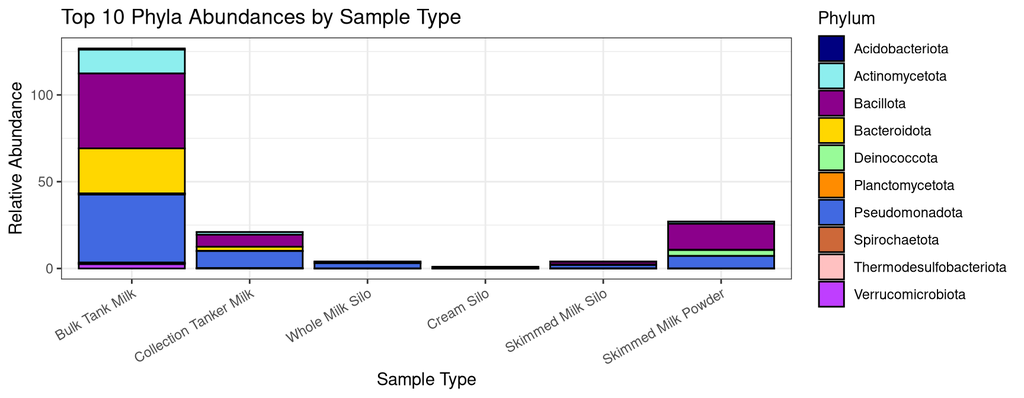

```r
#Note that here I had to add in specific colours into phylum_colors for the phyla that weren't specified in order to get the phyla to show up on my bar plot

# Create a plot
#Used this plot to sort out my phylum colours, make sure all the data is actually being seen/represented
phylum_df %>%
  filter(Phylum %in% top10_phyla) %>%
  group_by(environment_material, Phylum) %>%
  summarise(Abundance = sum(Abundance)) %>%
  ggplot(aes(x = environment_material, y = Abundance, fill = Phylum)) +
  geom_bar(stat = "identity", position = "stack", color = "black") +
  scale_fill_manual(values = phylum_colors) +
  labs(
    title = "Top 10 Phyla Abundances by Sample Type",
    x = "Sample Type",
    y = "Relative Abundance"
  ) +
  theme_bw() +
  theme(axis.text.x = element_text(angle = 30, hjust = 1, vjust = 1))
```

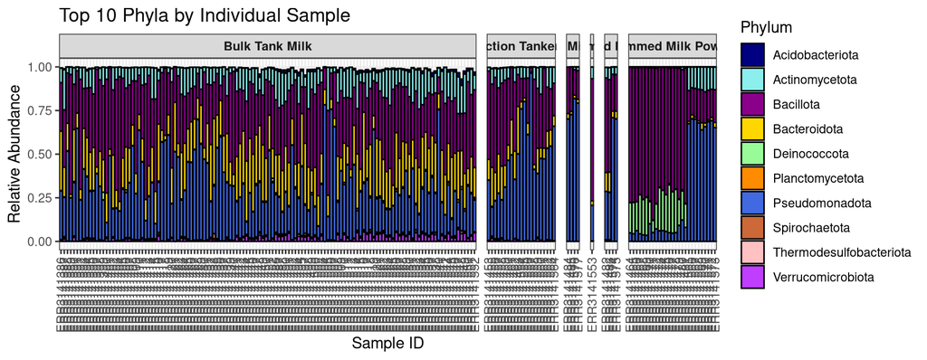

```r
#actual plot (by sample)
stacked_plot <- phylum_df %>%
  filter(Phylum %in% top10_phyla) %>%
  ggplot(aes(x = Sample, y = Abundance, fill = Phylum)) +
  geom_bar(stat = "identity", color = "black") +
  scale_y_continuous(limits = c(0, 1)) +
  facet_grid(. ~ environment_material, scales = "free_x", space = "free_x") +
  labs(title = "Top 10 Phyla by Individual Sample",
       y = "Relative Abundance", x = "Sample ID") +
  scale_fill_manual(values = phylum_colors) +
  theme_bw() +
  theme(axis.text.x = element_text(angle = 90, vjust = 0.5, hjust = 1),
        strip.text = element_text(face = "bold"),
        panel.spacing.x = unit(0.5, "lines"))

stacked_plot
```

Woah Nelly!! This is a crazy plot, but was expected because I have so many samples. To get a better sense of what’s going on I think in the next plot I am going to try and plot only the May samples and a separate plot with only the October samples.

One thing is really evident is that it looks like there is two really different compositions in term of relative abundance in the skimmed milk powder plots.

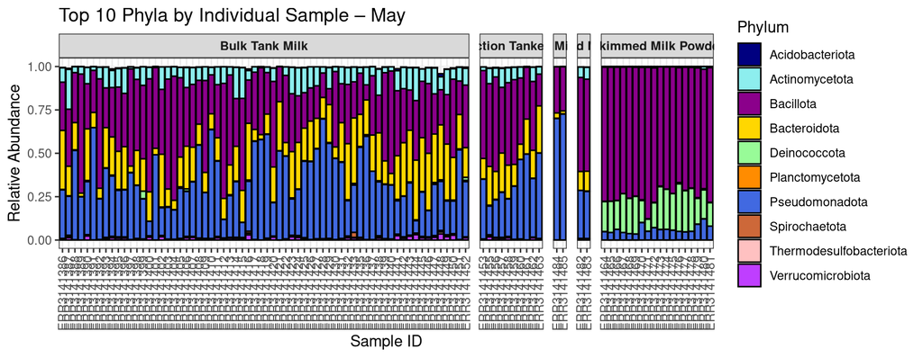

```r
#Plot May stacked bar chart
phylum_df %>%
  filter(Phylum %in% top10_phyla) %>%
  #Here is where we filter for May (month starts qith a 5)
  filter(grepl("^5", Collection_Date)) %>%
  ggplot(aes(x = Sample, y = Abundance, fill = Phylum)) +
  geom_bar(stat = "identity", color = "black") +
  scale_y_continuous(limits = c(0, 1)) +
  facet_grid(. ~ environment_material, scales = "free_x", space = "free_x") +
  labs(title = "Top 10 Phyla by Individual Sample – May",
       y = "Relative Abundance", x = "Sample ID") +
  scale_fill_manual(values = phylum_colors) +
  theme_bw() +
  theme(axis.text.x = element_text(angle = 90, vjust = 0.5, hjust = 1),
        strip.text = element_text(face = "bold"),
        panel.spacing.x = unit(0.5, "lines"))
```

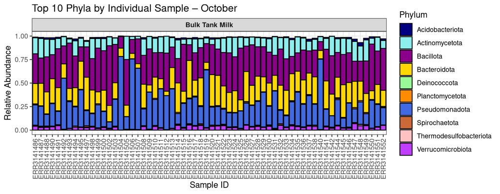

```r
#Plot October stacked bar chart
phylum_df %>%
  filter(Phylum %in% top10_phyla) %>%
  #Here is where we filter for October (month starts with a 10)
  filter(grepl("^10", Collection_Date)) %>%
  ggplot(aes(x = Sample, y = Abundance, fill = Phylum)) +
  geom_bar(stat = "identity", color = "black") +
  scale_y_continuous(limits = c(0, 1)) +
  facet_grid(. ~ environment_material, scales = "free_x", space = "free_x") +
  labs(title = "Top 10 Phyla by Individual Sample – October",
       y = "Relative Abundance", x = "Sample ID") +
  scale_fill_manual(values = phylum_colors) +
  theme_bw() +
  theme(axis.text.x = element_text(angle = 90, vjust = 0.5, hjust = 1),
        strip.text = element_text(face = "bold"),
        panel.spacing.x = unit(0.5, "lines"))
```

Success for May sample plot! For some reason only Bulk Tank Milk samples were plotted in October. If I have enough time I will come back and fix, but since I have already plotted a Top 10 Phyla plot I will continue on with my analysis for now.

## Faceted Bar plot

To help compare the phylum abundance between sample types, we can facet by phylum to better see how the changes occur across the stations, which is masked in the stacked bar plot. It’s a little better than the stacked bar plot, however, we can do even better!

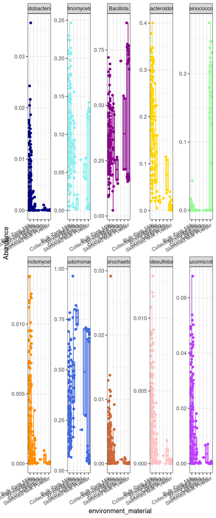

```r
phylum_df %>%
  dplyr::filter(Phylum %in% top10_phyla) %>%
  ggplot(aes(x = environment_material, y = Abundance, fill = Phylum, color = Phylum)) +
  facet_wrap(Phylum~., scale = "free", nrow = 2) +
  # add the stacked bar
  geom_jitter() +
  geom_boxplot(outlier.shape = NA, alpha = 0.5) +
  # change the colors to be our selected colors
  scale_fill_manual(values = phylum_colors) +
  scale_color_manual(values = phylum_colors) +
  theme_bw() +
  theme(legend.position = "none",
        axis.text.x = element_text(angle = 30, hjust = 1, vjust = 1))
```

```r
#save df of phyla
save(phylum_df,
     file = "data/07_Composition/phylum_df.RData")
```

INTERPRETATION #3: Make the above dotplot and boxplot for your sample types and your most abundant phyla. What *initial* conclusions can you draw regarding the sampled microbial communities as it relates to your scientific question?

This figure highlights some strong phylum-level differences between the different dairy sample types that were analyzed in this study.

The difference in relative abundance of these phyla between Whole Milk Silo samples and Skim Milk Silo samples got me thinking about what might cause these differences we are seeing. Could certain bacteria be associated with fat molecules in the milk? Similar to particle associated bacteria vs. free-living bacteria in water? This is something that wasn’t discussed in the paper but I just had a curious thought about! This might be hard to look at though, especially if there are fewer phyla in Skimmed Milk Powder samples, which could sort of give misleading results in a direct comparison.

Also I would be curious to look at the similarities between phyla that follow similar relative abundance patterns between sample types.

After initial exploration, we focus on specific phyla that appear to vary across sample type. I would like to follow up with these phyla that looked particularly interesting:

- Deinococcota
- Bacteroidota
- Pseudomonadota
- Bacillota

### A1. Deinococcota

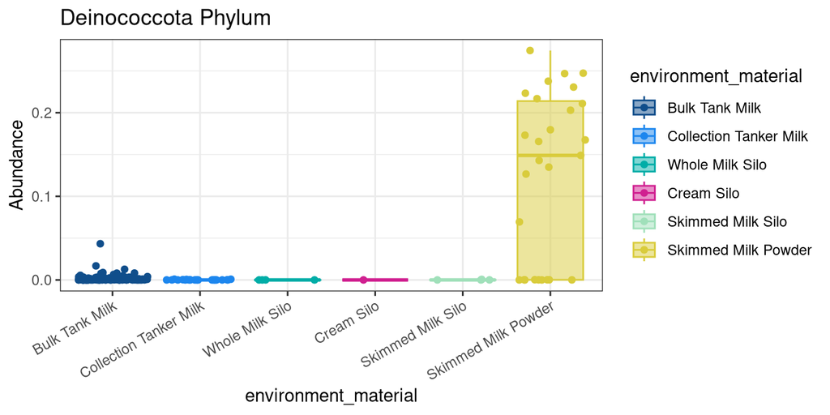

```r
# Narrow in on a specific group

deinococcota_df <-
  phylum_df %>%
  filter(Phylum == "Deinococcota")


# Deinococcota - y: abundance, x: sample, dot plot + boxplot
deinococcota_phylum_sample_type <-
  phylum_df %>%
  dplyr::filter(Phylum == "Deinococcota") %>%
  # build the plot
  ggplot(aes(x = environment_material, y = Abundance,
             fill = environment_material, color = environment_material)) +
  geom_boxplot(alpha = 0.5, outlier.shape = NA) + # outliers not plotted here in boxplot
  geom_jitter() +
  theme_bw() +
  labs(title = "Deinococcota Phylum") +
  scale_color_manual(values = environment_colors) +
  scale_fill_manual(values = environment_colors) +
    theme(axis.text.x = element_text(angle = 30, hjust = 1, vjust = 1),
          legend.position = "right")

#View
deinococcota_phylum_sample_type
```

Nice! We were able to look at the relative abundance of Deinococcota by sample type. Now I want to carry out some statistics to see if these differences are significant. Again, I want to mention the bimodal distribution of Deinococcota in the skimmed milk powder samples.

```r
#Shapiro-Wilk test for normality
deinococcota_df %>%
  # remove cream silo sample since it has fewer than three data points
  filter(environment_material != "Cream Silo") %>%
  group_by(environment_material) %>%
  filter(n() >= 3) %>%  # ensure enough samples per group for Shapiro test
  shapiro_test(Abundance)
```

```
## # A tibble: 5 × 4
##   environment_material   variable  statistic        p
##   <fct>                  <chr>         <dbl>    <dbl>
## 1 Bulk Tank Milk         Abundance     0.370 4.35e-21
## 2 Collection Tanker Milk Abundance     0.627 3.80e- 6
## 3 Whole Milk Silo        Abundance     0.630 1.24e- 3
## 4 Skimmed Milk Silo      Abundance     0.684 7.54e- 3
## 5 Skimmed Milk Powder    Abundance     0.849 1.08e- 3
```

Okay nice all p values were < 0.05 across all sample types, indicating that the data is not normally distributed.

I am now going to move forward with a Kruskal-Wallis test to see if there are significant between-group differences in relative abundance of Deinococcota. Followed by Dunn’s test.

```r
# Statistically: Kruskall-Wallis followed by post-hoc Dunn's test
# These are non-parametric (non-normal) stat tests

# Filter for just Deinococcota
deinococcota_df <-
  phylum_df %>%
  filter(Phylum == "Deinococcota")

# Kruskal-Wallis test
kruskal_deino <- deinococcota_df %>%
  kruskal_test(Abundance ~ environment_material)

# View result
kruskal_deino
```

```
## # A tibble: 1 × 6
##   .y.           n statistic    df            p method
## * <chr>     <int>     <dbl> <int>        <dbl> <chr>
## 1 Abundance   185      41.4     5 0.0000000778 Kruskal-Wallis
```

```r
# If significant (p < 0.05), run post-hoc Dunn's test
dunn_deino <- deinococcota_df %>%
  dunn_test(Abundance ~ environment_material, p.adjust.method = "fdr") %>%
  add_xy_position(x = "environment_material")

# View post-hoc results
dunn_deino
```

```
## # A tibble: 15 × 13
##    .y.       group1    group2    n1    n2 statistic       p   p.adj p.adj.signif
##    <chr>     <chr>     <chr>  <int> <int>     <dbl>   <dbl>   <dbl> <chr>
##  1 Abundance Bulk Tan… Colle…   128    21   -3.74   1.83e-4 1.24e-3 **
##  2 Abundance Bulk Tan… Whole…   128     4   -2.41   1.61e-2 4.01e-2 *
##  3 Abundance Bulk Tan… Cream…   128     1   -1.35   1.78e-1 2.97e-1 ns
##  4 Abundance Bulk Tan… Skimm…   128     4   -1.66   9.66e-2 1.81e-1 ns
##  5 Abundance Bulk Tan… Skimm…   128    27    3.50   4.70e-4 1.76e-3 **
##  6 Abundance Collecti… Whole…    21     4   -0.626  5.31e-1 7.49e-1 ns
##  7 Abundance Collecti… Cream…    21     1   -0.460  6.45e-1 7.49e-1 ns
##  8 Abundance Collecti… Skimm…    21     4    0.0682 9.46e-1 9.46e-1 ns
##  9 Abundance Collecti… Skimm…    21    27    5.57   2.50e-8 3.75e-7 ****
## 10 Abundance Whole Mi… Cream…     4     1   -0.116  9.08e-1 9.46e-1 ns
## 11 Abundance Whole Mi… Skimm…     4     4    0.536  5.92e-1 7.49e-1 ns
## 12 Abundance Whole Mi… Skimm…     4    27    3.66   2.48e-4 1.24e-3 **
## 13 Abundance Cream Si… Skimm…     1     4    0.454  6.49e-1 7.49e-1 ns
## 14 Abundance Cream Si… Skimm…     1    27    2.05   3.99e-2 8.55e-2 ns
## 15 Abundance Skimmed … Skimm…     4    27    2.96   3.10e-3 9.31e-3 **
## # ℹ 4 more variables: y.position <dbl>, groups <named list>, xmin <dbl>,
## #   xmax <dbl>
```

```r
#view(dunn_deino)
```

From these results we saw that Bulk Tank Milk differs significantly from Collection Tanker Milk, Whole Milk Silo, and Skimmed Milk Powder.

Skimmed Milk Silo and Whole Milk Silo show no significant difference in Abundance.

### A2. Bacteroidota

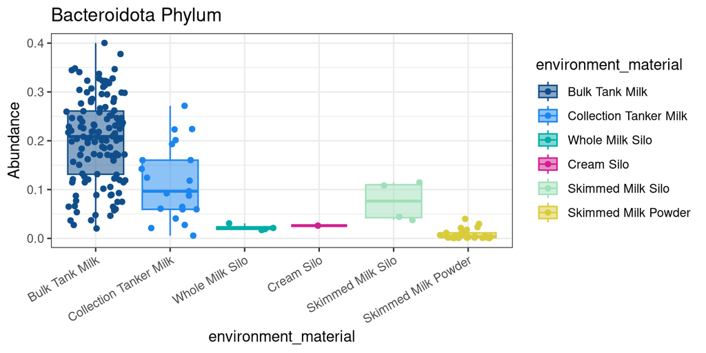

```r
# Narrow in on a specific group
# Bacteroidota - y: abundance, x: sample, dot plot + boxplot
bacteroidota_phylum_sample_type <-
  phylum_df %>%
  dplyr::filter(Phylum == "Bacteroidota") %>%
  # build the plot
  ggplot(aes(x = environment_material, y = Abundance,
             fill = environment_material, color = environment_material)) +
  geom_boxplot(alpha = 0.5, outlier.shape = NA) + # outliers not plotted here in boxplot
  geom_jitter() +
  theme_bw() +
  labs(title = "Bacteroidota Phylum") +
  scale_color_manual(values = environment_colors) +
  scale_fill_manual(values = environment_colors) +
    theme(axis.text.x = element_text(angle = 30, hjust = 1, vjust = 1),
          legend.position = "right")

#View
bacteroidota_phylum_sample_type
```

Now going to statistically test these differences with Kruskall-Wallis test followed by Dunn’s post-hoc test.

```r
# Statistically: Kruskall-Wallis followed by a Dunn's post-hoc test


# Filter for just Bacteroidota
bacteroidota_df <-
  phylum_df %>%
  filter(Phylum == "Bacteroidota")

# Kruskal-Wallis test
kruskal_bacteroid <- bacteroidota_df %>%
  kruskal_test(Abundance ~ environment_material)

# View result
kruskal_bacteroid
```

```
## # A tibble: 1 × 6
##   .y.           n statistic    df        p method
## * <chr>     <int>     <dbl> <int>    <dbl> <chr>
## 1 Abundance   185      92.4     5 2.11e-18 Kruskal-Wallis
```

```r
# If significant (p < 0.05), run post-hoc Dunn's test
dunn_bacteroid <- bacteroidota_df %>%
  dunn_test(Abundance ~ environment_material, p.adjust.method = "fdr") %>%
  add_xy_position(x = "environment_material")

# View post-hoc results
dunn_bacteroid
```

```
## # A tibble: 15 × 13
##    .y.       group1  group2    n1    n2 statistic        p    p.adj p.adj.signif
##    <chr>     <chr>   <chr>  <int> <int>     <dbl>    <dbl>    <dbl> <chr>
##  1 Abundance Bulk T… Colle…   128    21   -3.38   7.31e- 4 3.66e- 3 **
##  2 Abundance Bulk T… Whole…   128     4   -3.21   1.34e- 3 5.03e- 3 **
##  3 Abundance Bulk T… Cream…   128     1   -1.57   1.17e- 1 2.71e- 1 ns
##  4 Abundance Bulk T… Skimm…   128     4   -2.27   2.32e- 2 6.97e- 2 ns
##  5 Abundance Bulk T… Skimm…   128    27   -8.88   6.79e-19 1.02e-17 ****
##  6 Abundance Collec… Whole…    21     4   -1.53   1.27e- 1 2.71e- 1 ns
##  7 Abundance Collec… Cream…    21     1   -0.759  4.48e- 1 6.99e- 1 ns
##  8 Abundance Collec… Skimm…    21     4   -0.654  5.13e- 1 6.99e- 1 ns
##  9 Abundance Collec… Skimm…    21    27   -3.73   1.92e- 4 1.44e- 3 **
## 10 Abundance Whole … Cream…     4     1    0.0501 9.60e- 1 9.60e- 1 ns
## 11 Abundance Whole … Skimm…     4     4    0.673  5.01e- 1 6.99e- 1 ns
## 12 Abundance Whole … Skimm…     4    27   -0.470  6.38e- 1 7.98e- 1 ns
## 13 Abundance Cream … Skimm…     1     4    0.376  7.07e- 1 8.16e- 1 ns
## 14 Abundance Cream … Skimm…     1    27   -0.302  7.62e- 1 8.17e- 1 ns
## 15 Abundance Skimme… Skimm…     4    27   -1.36   1.74e- 1 3.27e- 1 ns
## # ℹ 4 more variables: y.position <dbl>, groups <named list>, xmin <dbl>,
## #   xmax <dbl>
```

Significant comparisons for Bacteroidota:

Bulk Tank Milk vs. Collection Tanker Milk

Bulk Tank Milk vs. Whole Milk Silo

**Bulk Tank Milk vs. Skimmed Milk Powder**

**Collection Tanker Milk vs. Skimmed Milk Powder**

### A3. Pseudomonadota

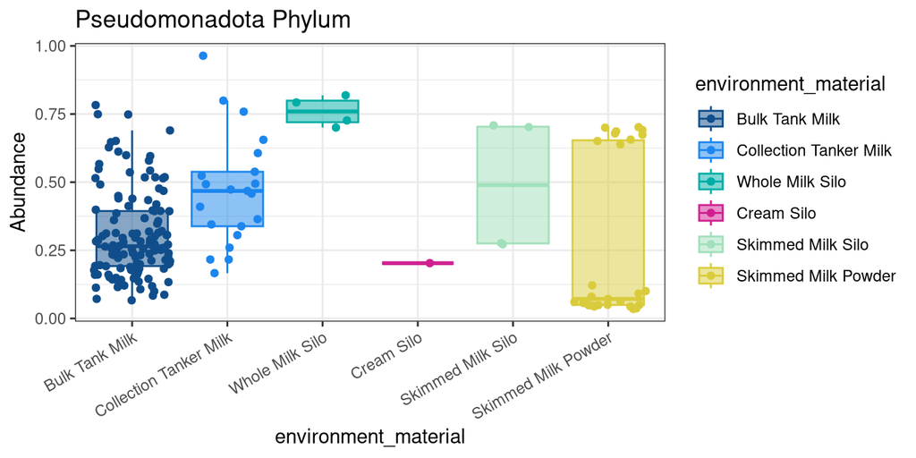

```r
# Narrow in on a specific group
# Pseudomonadota - y: abundance, x: sample, dot plot + boxplot
pseudomonadota_phylum_sample_type <-
  phylum_df %>%
  dplyr::filter(Phylum == "Pseudomonadota") %>%
  # build the plot
  ggplot(aes(x = environment_material, y = Abundance,
             fill = environment_material, color = environment_material)) +
  geom_boxplot(alpha = 0.5, outlier.shape = NA) + # outliers not plotted here in boxplot
  geom_jitter() +
  theme_bw() +
  labs(title = "Pseudomonadota Phylum") +
  scale_color_manual(values = environment_colors) +
  scale_fill_manual(values = environment_colors) +
    theme(axis.text.x = element_text(angle = 30, hjust = 1, vjust = 1),
          legend.position = "right")

#View
pseudomonadota_phylum_sample_type
```

```r
# Statistically: Kruskall-Wallis followed by a Dunn's post-hoc test


# Filter for just Pseudomonadota
pseudo_df <-
  phylum_df %>%
  filter(Phylum == "Pseudomonadota")

# Kruskal-Wallis test
kruskal_pseudo <- pseudo_df %>%
  kruskal_test(Abundance ~ environment_material)

# View result
kruskal_pseudo
```

```
## # A tibble: 1 × 6
##   .y.           n statistic    df          p method
## * <chr>     <int>     <dbl> <int>      <dbl> <chr>
## 1 Abundance   185      31.6     5 0.00000725 Kruskal-Wallis
```

```r
# If significant (p < 0.05), run post-hoc Dunn's test
dunn_pseudo <- pseudo_df %>%
  dunn_test(Abundance ~ environment_material, p.adjust.method = "fdr") %>%
  add_xy_position(x = "environment_material")

# View post-hoc results
dunn_pseudo
```

```
## # A tibble: 15 × 13
##    .y.       group1    group2    n1    n2 statistic       p   p.adj p.adj.signif
##    <chr>     <chr>     <chr>  <int> <int>     <dbl>   <dbl>   <dbl> <chr>
##  1 Abundance Bulk Tan… Colle…   128    21    3.13   1.77e-3 6.64e-3 **
##  2 Abundance Bulk Tan… Whole…   128     4    3.29   1.02e-3 5.10e-3 **
##  3 Abundance Bulk Tan… Cream…   128     1   -0.589  5.56e-1 6.41e-1 ns
##  4 Abundance Bulk Tan… Skimm…   128     4    1.64   1.01e-1 1.69e-1 ns
##  5 Abundance Bulk Tan… Skimm…   128    27   -2.34   1.91e-2 4.78e-2 *
##  6 Abundance Collecti… Whole…    21     4    1.71   8.76e-2 1.64e-1 ns
##  7 Abundance Collecti… Cream…    21     1   -1.30   1.95e-1 2.77e-1 ns
##  8 Abundance Collecti… Skimm…    21     4    0.176  8.60e-1 9.21e-1 ns
##  9 Abundance Collecti… Skimm…    21    27   -4.24   2.28e-5 3.43e-4 ***
## 10 Abundance Whole Mi… Cream…     4     1   -2.02   4.33e-2 9.27e-2 ns
## 11 Abundance Whole Mi… Skimm…     4     4   -1.18   2.37e-1 2.97e-1 ns
## 12 Abundance Whole Mi… Skimm…     4    27   -4.04   5.36e-5 4.02e-4 ***
## 13 Abundance Cream Si… Skimm…     1     4    1.27   2.03e-1 2.77e-1 ns
## 14 Abundance Cream Si… Skimm…     1    27    0.0937 9.25e-1 9.25e-1 ns
## 15 Abundance Skimmed … Skimm…     4    27   -2.48   1.32e-2 3.95e-2 *
## # ℹ 4 more variables: y.position <dbl>, groups <named list>, xmin <dbl>,
## #   xmax <dbl>
```

Significant results for Pseudomonadota:

Bulk Tank Milk vs. Collection Tanker Milk  
Bulk Tank Milk vs. Whole Milk Silo  
Bulk Tank Milk vs. Skimmed Milk Powder  
Collection Tanker Milk vs. Skimmed Milk Powder Whole Milk Silo vs. Skimmed Milk Powder Skimmed Milk Silo vs. Skimmed Milk Powder

### A4. Bacillota

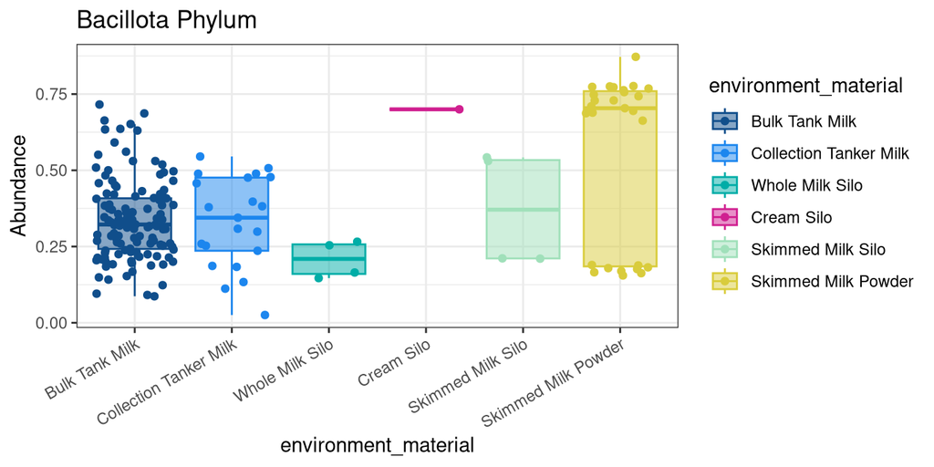

```r
# Narrow in on a specific group
# Bacillota - y: abundance, x: sample, dot plot + boxplot
bacillota_phylum_sample_type <-
  phylum_df %>%
  dplyr::filter(Phylum == "Bacillota") %>%
  # build the plot
  ggplot(aes(x = environment_material, y = Abundance,
             fill = environment_material, color = environment_material)) +
  geom_boxplot(alpha = 0.5, outlier.shape = NA) + # outliers not plotted here in boxplot
  geom_jitter() +
  theme_bw() +
  labs(title = "Bacillota Phylum") +
  scale_color_manual(values = environment_colors) +
  scale_fill_manual(values = environment_colors) +
    theme(axis.text.x = element_text(angle = 30, hjust = 1, vjust = 1),
          legend.position = "right")

#View
bacillota_phylum_sample_type
```

```r
# Statistically: Kruskall-Wallis followed by a Tukey's Posthoc test
# These are non-parametric (non-normal) stat tests
```

```r
# Statistically: Kruskall-Wallis followed by a Dunn's post-hoc test


# Filter for just Bacillota
bacillota_df <-
  phylum_df %>%
  filter(Phylum == "Bacillota")

# Kruskal-Wallis test
kruskal_bacillota <- bacillota_df %>%
  kruskal_test(Abundance ~ environment_material)

# View result
kruskal_bacillota
```

```
## # A tibble: 1 × 6
##   .y.           n statistic    df       p method
## * <chr>     <int>     <dbl> <int>   <dbl> <chr>
## 1 Abundance   185      16.4     5 0.00582 Kruskal-Wallis
```

```r
# If significant (p < 0.05), run post-hoc Dunn's test
dunn_bacillota <- bacillota_df %>%
  dunn_test(Abundance ~ environment_material, p.adjust.method = "fdr") %>%
  add_xy_position(x = "environment_material")

# View post-hoc results
dunn_bacillota
```

```
## # A tibble: 15 × 13
##    .y.       group1     group2    n1    n2 statistic       p  p.adj p.adj.signif
##    <chr>     <chr>      <chr>  <int> <int>     <dbl>   <dbl>  <dbl> <chr>
##  1 Abundance Bulk Tank… Colle…   128    21   -0.0509 0.959   0.959  ns
##  2 Abundance Bulk Tank… Whole…   128     4   -1.94   0.0522  0.156  ns
##  3 Abundance Bulk Tank… Cream…   128     1    1.52   0.130   0.224  ns
##  4 Abundance Bulk Tank… Skimm…   128     4    0.256  0.798   0.855  ns
##  5 Abundance Bulk Tank… Skimm…   128    27    3.07   0.00216 0.0170 *
##  6 Abundance Collectio… Whole…    21     4   -1.79   0.0742  0.186  ns
##  7 Abundance Collectio… Cream…    21     1    1.50   0.134   0.224  ns
##  8 Abundance Collectio… Skimm…    21     4    0.260  0.795   0.855  ns
##  9 Abundance Collectio… Skimm…    21    27    2.27   0.0230  0.0935 ns
## 10 Abundance Whole Mil… Cream…     4     1    2.24   0.0249  0.0935 ns
## 11 Abundance Whole Mil… Skimm…     4     4    1.58   0.115   0.224  ns
## 12 Abundance Whole Mil… Skimm…     4    27    3.05   0.00227 0.0170 *
## 13 Abundance Cream Silo Skimm…     1     4   -1.24   0.213   0.320  ns
## 14 Abundance Cream Silo Skimm…     1    27   -0.856  0.392   0.490  ns
## 15 Abundance Skimmed M… Skimm…     4    27    0.970  0.332   0.453  ns
## # ℹ 4 more variables: y.position <dbl>, groups <named list>, xmin <dbl>,
## #   xmax <dbl>
```

Significant results for bacillota:

Skimmed Milk Powder vs. Bulk Tank Milk

Skimmed MIlke Powder vs. Whole Milk Silo

INTERPRETATION #4: Based on these phylum-level analyses, were there any phyla that you were able to identify to focus on moving forward for deeper taxonomic analyses? Why?

Note that I also followed up with Bacteroidota!

## B. Genus

Let’s first calculate the genus data frame.

```r
# Calculate the Family relative abundance
# Note: The read depth MUST be normalized in some way: scale_reads
genus_df <-
  scaled_physeq %>%
  # agglomerate at the phylum level
  tax_glom(taxrank = "Genus") %>%
  # Transform counts to relative abundance
  transform_sample_counts(function (x) {x/sum(x)}) %>%
  # Melt to a long format
  psmelt() %>%
  mutate(environment_material = fct_relevel(environment_material, c(
    "Bulk Tank Milk", "Collection Tanker Milk", "Whole Milk Silo", "Cream Silo", "Skimmed Milk Silo", "Skimmed Milk Powder")))

# Save df of genera
save(genus_df,
     file = "data/07_Composition/genus_df.RData")
```

### Deinococcota Genera

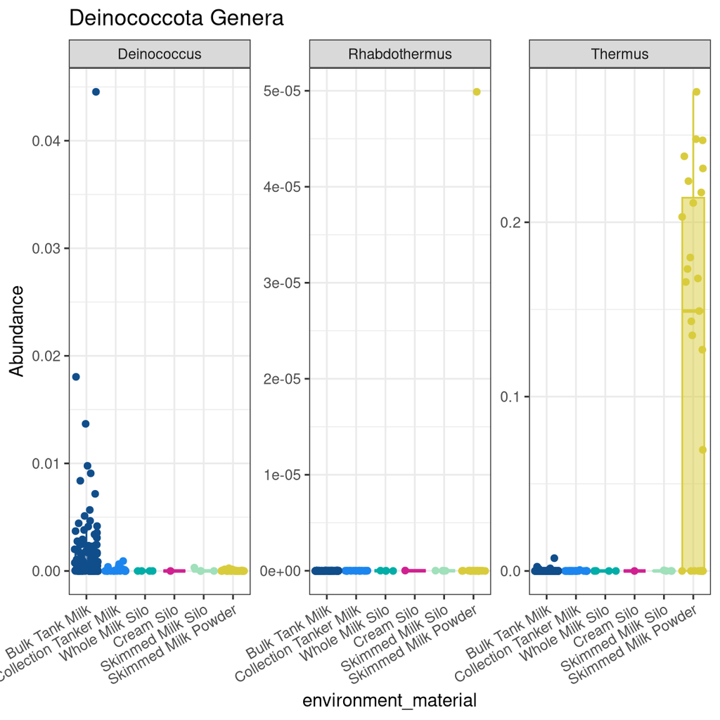

```r
# Deinococcota
# Plot genus
deino_genus_sample_type <-
  genus_df %>%
  dplyr::filter(Phylum == "Deinococcota") %>%
  # At first, plot all of the genera and then subset the ones that have intersting trends
  #dplyr::filter(Genus %in% c("hgcI clade", "CL500-29 marine group")) %>%
  # build the plot
  ggplot(aes(x = environment_material, y = Abundance,
             fill = environment_material, color = environment_material)) +
  facet_wrap(.~Genus, scales = "free_y", nrow = 1) +
  geom_boxplot(alpha = 0.5, outlier.shape = NA) + # outliers not plotted here in boxplot
  geom_jitter() +
  theme_bw() +
  labs(title = "Deinococcota Genera") +
  scale_color_manual(values = environment_colors) +
  scale_fill_manual(values = environment_colors) +
  theme(axis.text.x = element_text(angle = 30, hjust = 1, vjust = 1),
        legend.position = "none")

#View it!
deino_genus_sample_type
```

Wow wow wow!! I’m so glad I plotted at the level of genus - you can see that the relative abundance of Deinococcota in the Skimmed Milk Powder samples is essentially entirely represented by the genus Thermus - so cool!

Since these results are so cool I’m also going to follow up with looking at Bacteroidota at the genus level.

### Bacteroidota Genera

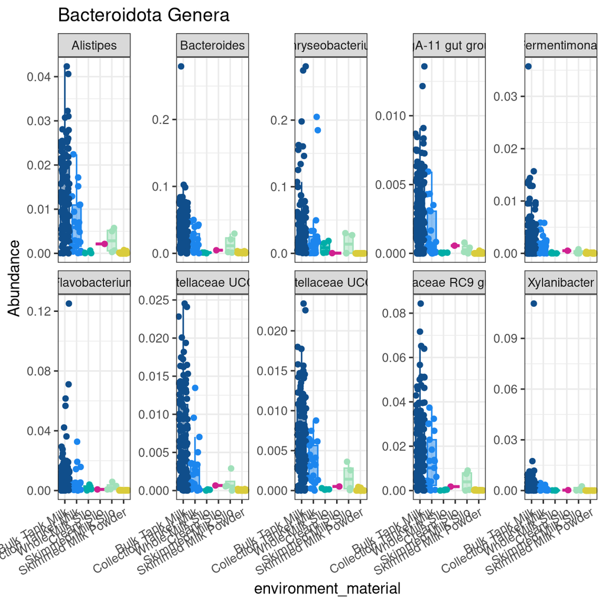

```r
# Bacteroidota
# Plot genus
top_genera <- genus_df %>%
  filter(Phylum == "Bacteroidota") %>%
  group_by(Genus) %>%
  summarize(mean_abund = mean(Abundance, na.rm = TRUE)) %>%
  arrange(desc(mean_abund)) %>%
  slice_head(n = 10) %>%
  pull(Genus)

bacteroid_genus_sample_type <- genus_df %>%
  filter(Phylum == "Bacteroidota", Genus %in% top_genera) %>%
  ggplot(aes(x = environment_material, y = Abundance,
             fill = environment_material, color = environment_material)) +
  facet_wrap(~ Genus, scales = "free_y", nrow = 2) +  # match layout
  geom_boxplot(alpha = 0.5, outlier.shape = NA) +
  geom_jitter() +
  theme_bw() +
  labs(title = "Bacteroidota Genera") +
  scale_color_manual(values = environment_colors) +
  scale_fill_manual(values = environment_colors) +
  theme(
    axis.text.x = element_text(angle = 30, hjust = 1, vjust = 1),
    legend.position = "none"
  )

# View it
bacteroid_genus_sample_type
```

```r
#See how many genera in Bacteroidota because I am curious
genus_df %>%
  filter(Phylum == "Bacteroidota") %>%
  distinct(Genus) %>%
  nrow()
```

```
## [1] 195
```

Okay a few quick notes here! I struggled so much to get this plot together, and I think it was because there were way to many genera to be displayed on one plot (it looked like a mess of random numbers when I plotted it). So, I then went and selected the 10 genera with the highest relative abundance. I also was curious to see how many Bacteroidota genera were there, and I found out there were 195! Wow!

Okay, now my goal is to create a plot that looks at the relative abundance of three specific genera (Pseudomonas, Lactococcus and Acinetobacter) in isolation across the different sample types. I selected these three specific genera because they are discussed in the paper as being genera with psychrotrophic, food spoilage-associated genera.

Reminder of my hypothesis: Refrigerated storage (pre-pasteurization) will result in an increased relative abundance of psychrotrophic spoilage-associated bacteria. After pasteurization, these psychrotrophic bacteria will diminish.

First I want to look at the genus Pseudomonas separately by sample type.

### A4. Pseudomonas

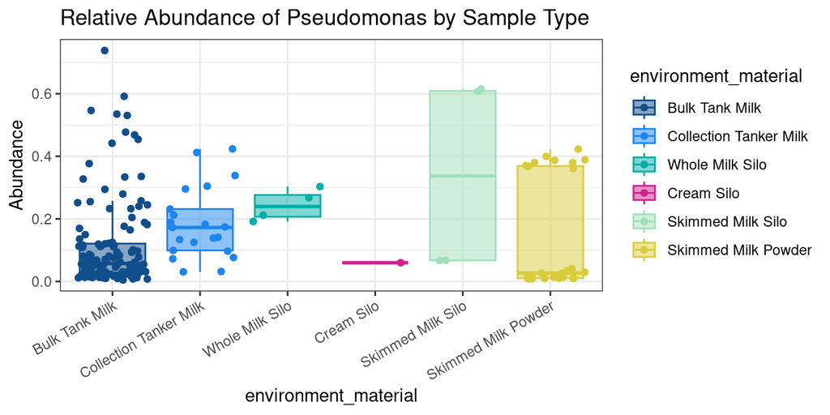

```r
# Narrow in on a specific group
# Pseudomonas - y: abundance, x: sample, dot plot + boxplot
pseudomonas_genus_sample_type <-
  genus_df %>%
  dplyr::filter(Genus == "Pseudomonas") %>%
  # build the plot
  ggplot(aes(x = environment_material, y = Abundance,
             fill = environment_material, color = environment_material)) +
  geom_boxplot(alpha = 0.5, outlier.shape = NA) + # outliers not plotted here in boxplot
  geom_jitter() +
  theme_bw() +
  labs(title = "Relative Abundance of Pseudomonas by Sample Type") +
  scale_color_manual(values = environment_colors) +
  scale_fill_manual(values = environment_colors) +
    theme(axis.text.x = element_text(angle = 30, hjust = 1, vjust = 1),
          legend.position = "right")

#View
pseudomonas_genus_sample_type
```

Followed by looking at the genus Acinetobacter in isolation.

### Acinetobacter

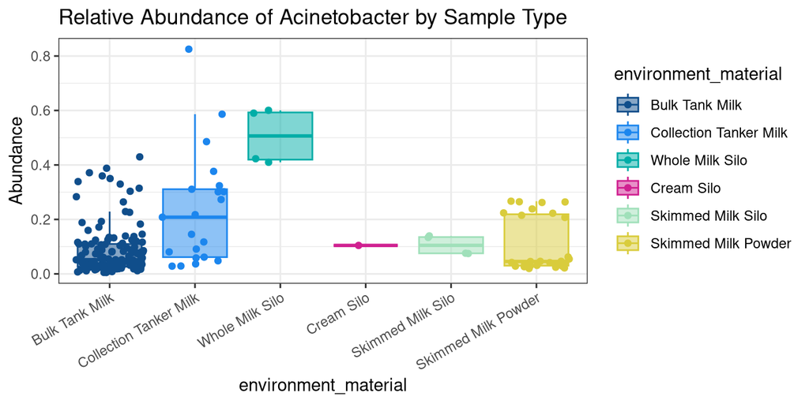

```r
# Narrow in on a specific group
# acinetobacter - y: abundance, x: sample, dot plot + boxplot
acinetobacter_genus_sample_type <-
  genus_df %>%
  dplyr::filter(Genus == "Acinetobacter") %>%
  # build the plot
  ggplot(aes(x = environment_material, y = Abundance,
             fill = environment_material, color = environment_material)) +
  geom_boxplot(alpha = 0.5, outlier.shape = NA) + # outliers not plotted here in boxplot
  geom_jitter() +
  theme_bw() +
  labs(title = "Relative Abundance of Acinetobacter by Sample Type") +
  scale_color_manual(values = environment_colors) +
  scale_fill_manual(values = environment_colors) +
    theme(axis.text.x = element_text(angle = 30, hjust = 1, vjust = 1),
          legend.position = "right")

#View
acinetobacter_genus_sample_type
```

Next I looked at the relative abundance of Lactococcus in isolation across sample types.

### Lactococcus

[figure not shown]

```r
# Narrow in on a specific group
# lactococcus - y: abundance, x: sample, dot plot + boxplot
lactococcus_genus_sample_type <-
  genus_df %>%
  dplyr::filter(Genus == "Lactococcus") %>%
  # build the plot
  ggplot(aes(x = environment_material, y = Abundance,
             fill = environment_material, color = environment_material)) +
  geom_boxplot(alpha = 0.5, outlier.shape = NA) + # outliers not plotted here in boxplot
  geom_jitter() +
  theme_bw() +
  labs(title = "Relative Abundance of Lactococcus by Sample Type") +
  scale_color_manual(values = environment_colors) +
  scale_fill_manual(values = environment_colors) +
    theme(axis.text.x = element_text(angle = 30, hjust = 1, vjust = 1),
          legend.position = "right")

#View
pseudomonas_genus_sample_type + lactococcus_genus_sample_type + acinetobacter_genus_sample_type
```

This was really interesting to see. Although I don’t think I have enough time to run stats on this plot I do want to make some initial interpretations about it!

Based on the results originally presented in the paper, I made the hypothesis that refrigerated storage (pre-pasteurization) will result in an increased relative abundance of psychrotrophic spoilage-associated bacteria. After pasteurization, these psychrotrophic bacteria will diminish.

**Note**: Psychrotrophic bacteria describe bacteria that can grow at temperatures equal to or lower than 7°C.

To do this I looked at three different genera that are widely known to contain many species of typical psychrophilic spoilage bacteria. I hypothesized that when milk is stored at cold temperatures there will be an increased relative abundance/ dominance of psychrotrophic spoilage-associated bacteria. But after pasteurization (heat treatment process that uses high temperatures to kill harmful microorganisms, prevent spoilage and extend shelf life).

By looking at the graphs (without stats to indicate significance of results) I found that as a general trend, refrigerated storage (pre-pasteurization) results in an increased relative abundance of Pseudomonas, Acinetobacter and Lactococcus. ALthough the increase in Lactococcus is visually much less pronounced than Pseudomonas or Lactococcus.

SOmething really interesting that I saw was that the relative abundance of these psychrotrophic food-spoilage associated bacteria is not always diminished after pasteurization like I had hypothesized. In Pseudomonas it actualloy looks like there is a pretty big increase AFTER pasteurization.

If I had more time beofre this project was due I would really be interested in running statistics on these plots and looking further into this result by filtering down to the ASV level.

I then focused my genus-leval analysis on two themrophilic genera, Geobacillus and Thermus, in order to explore my second hypothesis: Skim milk powder will be enriched with thermophilic genera.

Starting with Geobacillus.

### Geobacillus

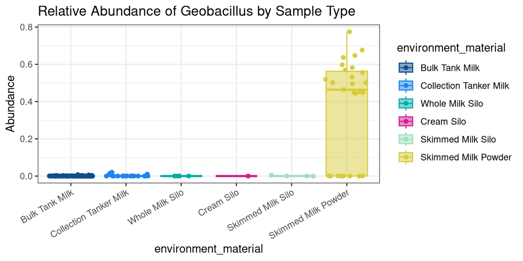

```r
# Narrow in on a specific group
# geobacillus - y: abundance, x: sample, dot plot + boxplot
geobacillus_genus_sample_type <-
  genus_df %>%
  dplyr::filter(Genus == "Geobacillus") %>%
  # build the plot
  ggplot(aes(x = environment_material, y = Abundance,
             fill = environment_material, color = environment_material)) +
  geom_boxplot(alpha = 0.5, outlier.shape = NA) + # outliers not plotted here in boxplot
  geom_jitter() +
  theme_bw() +
  labs(title = "Relative Abundance of Geobacillus by Sample Type") +
  scale_color_manual(values = environment_colors) +
  scale_fill_manual(values = environment_colors) +
    theme(axis.text.x = element_text(angle = 30, hjust = 1, vjust = 1),
          legend.position = "right")

#View
geobacillus_genus_sample_type
```

Great, now looking at Thermus.

### Thermus

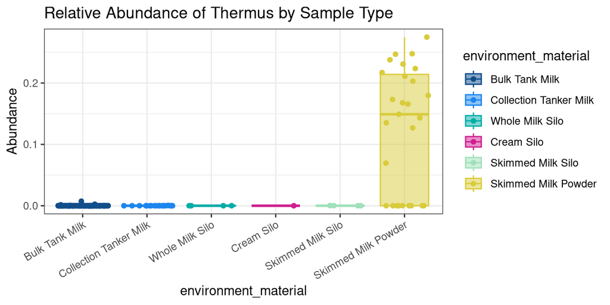

```r
# Narrow in on a specific group
# thermus - y: abundance, x: sample, dot plot + boxplot
thermus_genus_sample_type <-
  genus_df %>%
  dplyr::filter(Genus == "Thermus") %>%
  # build the plot
  ggplot(aes(x = environment_material, y = Abundance,
             fill = environment_material, color = environment_material)) +
  geom_boxplot(alpha = 0.5, outlier.shape = NA) + # outliers not plotted here in boxplot
  geom_jitter() +
  theme_bw() +
  labs(title = "Relative Abundance of Thermus by Sample Type") +
  scale_color_manual(values = environment_colors) +
  scale_fill_manual(values = environment_colors) +
    theme(axis.text.x = element_text(angle = 30, hjust = 1, vjust = 1),
          legend.position = "right")

#View
thermus_genus_sample_type
```

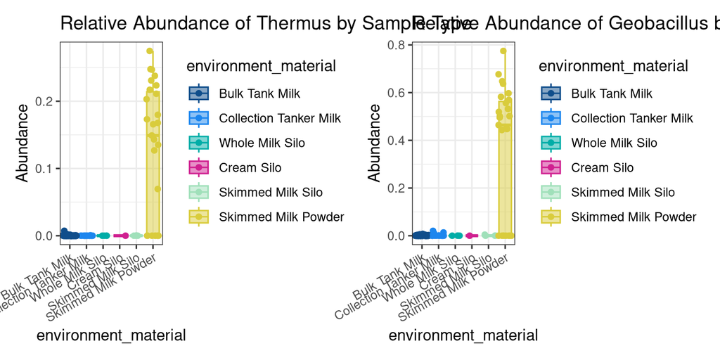

```r
#plot together

thermus_genus_sample_type + geobacillus_genus_sample_type
```

From this plot we see that skim milk powder has increased relative abundance of both Thermos and Geobacillus. Something we also see here is a bimodal distribution in the relative abundance of both of these genera, which has been a trend for the relative abundances in quite a few of the genera we have looked at.

**Note**: This following analysis was done for the homework before I really focused in on these two hypotheses ahead of the presentation. I left it in the document in addition to the other analysis I have done.

INTERPRETATION #5: Please make some plots of mid-level taxonomic ranks (e.g. Genus, Family, Order) as it relates to your scientific question. Were there any changes in the mid-level taxonomic trends compared to the phylum-level results? What does that tell you about that taxonomic group?

Scientific Question: How is microbial biodiversity modified as milk is processed in the dairy supply chain?

Wow! This mid-level taxonomic analysis was really cool, felt like I was teasing out important information about the makeup of the microbial communities present in these samples. I will definitely further this analysis before my presentation, but for now will focus my interpretation on two genus-level plots (Deinococcota and Bacteroidota).

*Deinococcota*: Once I broke down the Deinococcota phylum into genera, I saw that three different genera, Deinococcus, Rhabdothermus, and Thermus, were represented in our samples. When I looked at Deinococcota at the phylum level, it was one of the few phyla where there was low relative abundance in all sample types *except* the Skimmed Milk Powder samples. The most consistent trend we saw across the top ten most abundant phyla was that they had a higher relative abundance in the least processed samples and less abundance in the more processed Skim Milk Powder samples.

When we broke the Deinococcota phylum down into genera, we see that we do not see the trend we observed at the phylum level for the genera Deinococcus or Rhabdothermus, BUT we do see this trend in the genus Thermus!! It seems as though Thermus is the only genus contributing to the trend we saw at the phylum level! I’m excited to do a bit of a literature review to see if I can identify a reason why Thermus might have much higher relative abundance in Skim Milk Powder vs Bulk Tank Milk!

*Bacteroidota*:

Like I mentioned above in my document, I really struggled to make this plot of the relative abundance of the Bacteroidota genera! This was because there were SO MANY Bacteroidota genera represented in these samples - 195 genera to be exact!! That is a tad different than the three Deinococcota genera represented by our samples. In order to get around this, I thought the best strategy would be to look at the top ten most abundant genera in Bacteroidota. It was cool to see in these plots, that overall the trends in relative abundance for the genera were the same as the overall trend we saw for Bacteroidota across the different sample types at the phylum level. Bacteroides and Chryseobacterium has the highest relative of these top ten genera.

# C. ASV level

Now, let’s take a look at the ASVs. This is where the *real* ecology/biology happens! This is because the ASV-level plots will provide us with a more detailed view of **which specific taxa (ASVs) are driving the overall trends seen at the higher taxonomic levels (e.g. phylum)**.

Of course, if we had more time in class, we could run differential abundance and this would also help us to identify and statistically test which ASVs are important and also help us narrow on specific ASVs.

The goal with this lesson is to do some data exploration and then also test ASVs that are relevant for our specific study. Let’s go!

```r
# Note: The read depth MUST be normalized in some way: scale_reads
ASV_df <-
  scaled_physeq %>%
  # Prune out ASVs that have fewer than 100 counts!
  ## LOOK AT HOW MANY ARE REMOVED! We scaled to 20090 reads!
  prune_taxa(taxa_sums(.) >= 2009, .) %>%
  # agglomerate at the phylum level
  tax_glom(taxrank = "ASV") %>%
  # Transform counts to relative abundance
  transform_sample_counts(function (x) {x/sum(x)}) %>%
  # Melt to a long format
  psmelt() %>%
  # fix the order of date
  mutate(environment_material = fct_relevel(environment_material, c(
    "Bulk Tank Milk", "Collection Tanker Milk", "Whole Milk Silo", "Cream Silo", "Skimmed Milk Silo", "Skimmed Milk Powder")))

#View
ASV_df
```

```
##            OTU     Sample  Abundance Assay.Type AvgSpotLen     Bases BioProject
## 1200  ASV_0007 ERR3141506 0.76850957   AMPLICON        502  71209202 PRJEB31110
## 268   ASV_0002 ERR3141557 0.75485535   AMPLICON        502  80452026 PRJEB31110
## 477   ASV_0003 ERR3141389 0.64176856   AMPLICON        502 112309448 PRJEB31110
## 16696 ASV_0091 ERR3141502 0.57203448   AMPLICON        502  68422600 PRJEB31110
## 141   ASV_0001 ERR3141471 0.56620120   AMPLICON        502  80808446 PRJEB31110
## 385   ASV_0003 ERR3141403 0.56139119   AMPLICON        502  65366926 PRJEB31110
## 7251  ASV_0040 ERR3141440 0.56059131   AMPLICON        502  85907762 PRJEB31110
## 4429  ASV_0024 ERR3141400 0.53210097   AMPLICON        502  72144428 PRJEB31110
## 17801 ASV_0097 ERR3141450 0.51971001   AMPLICON        502 124635054 PRJEB31110
## 368   ASV_0002 ERR3141576 0.50877733   AMPLICON        502  76644356 PRJEB31110
## 415   ASV_0003 ERR3141525 0.50357870   AMPLICON        502 143658846 PRJEB31110
## 25    ASV_0001 ERR3141472 0.50153406   AMPLICON        502  98749424 PRJEB31110
## 974   ASV_0006 ERR3141417 0.49875460   AMPLICON        502  78177464 PRJEB31110
## 315   ASV_0002 ERR3141577 0.49791883   AMPLICON        502  90787704 PRJEB31110
```

[output cut: 27274 more lines]

### C. Deinococcota ASVs

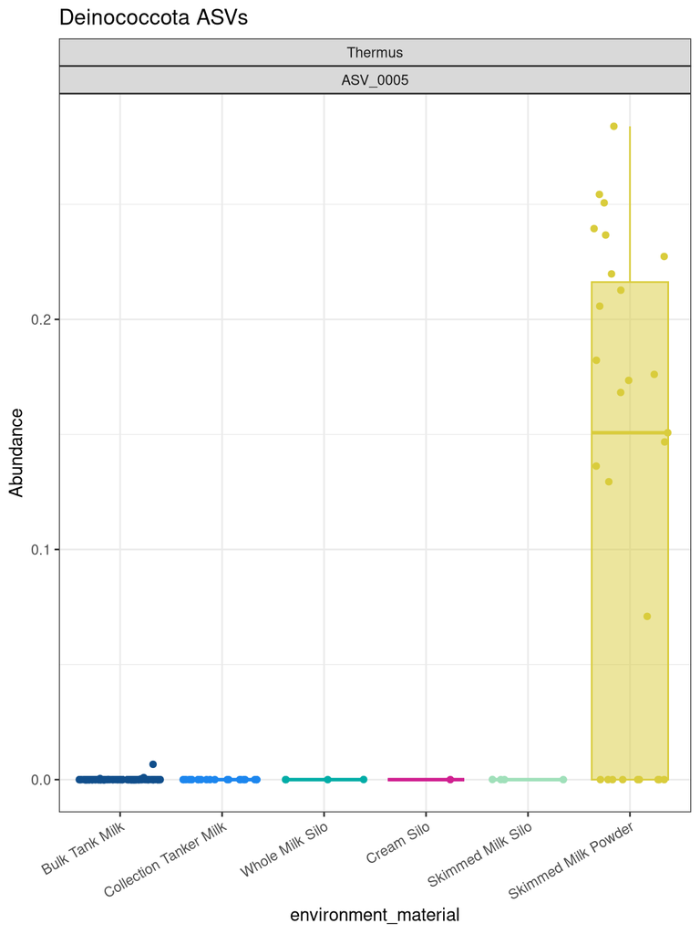

```r
# Calculate top couple of ASVs
# Make a list of phyla the top phyla
top_deino_ASVs <-
  ASV_df %>%
  dplyr::filter(Phylum == "Deinococcota") %>%
  group_by(ASV) %>%
  summarize(mean_Abundance = mean(Abundance)) %>%
  dplyr::filter(mean_Abundance > 0.005) %>%
  pull(ASV)

# Deinococcota
# Plot ASVs
deino_asv_sample_type <-
  ASV_df %>%
  dplyr::filter(ASV %in% top_deino_ASVs) %>%
  # build the plot
  ggplot(aes(x = environment_material, y = Abundance,
             fill = environment_material, color = environment_material)) +
  facet_wrap(Genus~ASV, scales = "free_y", nrow = 2) +
  geom_boxplot(alpha = 0.5, outlier.shape = NA) + # outliers not plotted here in boxplot
  geom_jitter() +
  theme_bw() +
  labs(title = "Deinococcota ASVs") +
  scale_color_manual(values = environment_colors) +
  scale_fill_manual(values = environment_colors) +
  theme(axis.text.x = element_text(angle = 30, hjust = 1, vjust = 1),
        legend.position = "none")

deino_asv_sample_type
```

### C. Bacteroidota ASVs

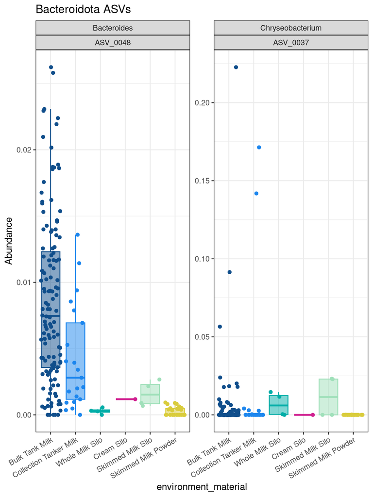

```r
# Calculate top couple of ASVs
# Make a list of phyla the top phyla
top_bacteroid_ASVs <-
  ASV_df %>%
  dplyr::filter(Phylum == "Bacteroidota") %>%
  group_by(ASV) %>%
  summarize(mean_Abundance = mean(Abundance)) %>%
  dplyr::filter(mean_Abundance > 0.005) %>%
  pull(ASV)

# Bacteroidota
# Plot ASVs
bacteroid_asv_sample_type <-
  ASV_df %>%
  dplyr::filter(ASV %in% top_bacteroid_ASVs) %>%
  # build the plot
  ggplot(aes(x = environment_material, y = Abundance,
             fill = environment_material, color = environment_material)) +
  #changed rows from 2 to 1; only two plots! (nrow = 1)
  facet_wrap(Genus~ASV, scales = "free_y", nrow = 1) +
  geom_boxplot(alpha = 0.5, outlier.shape = NA) + # outliers not plotted here in boxplot
  geom_jitter() +
  theme_bw() +
  labs(title = "Bacteroidota ASVs") +
  scale_color_manual(values = environment_colors) +
  scale_fill_manual(values = environment_colors) +
  theme(axis.text.x = element_text(angle = 30, hjust = 1, vjust = 1),
        legend.position = "none")

#View
bacteroid_asv_sample_type
```

Identifying the 10 most abundant ASVs:

```r
#identify my top ten ASVs
top_asvs <- names(sort(taxa_sums(scaled_physeq), decreasing = TRUE))[1:10]

#View my top 10 ASVs
top_asvs
```

```
##  [1] "ASV_0003" "ASV_0001" "ASV_0002" "ASV_0004" "ASV_0007" "ASV_0006"
##  [7] "ASV_0005" "ASV_0009" "ASV_0008" "ASV_0011"
```

##Plotting most abundant ASVs

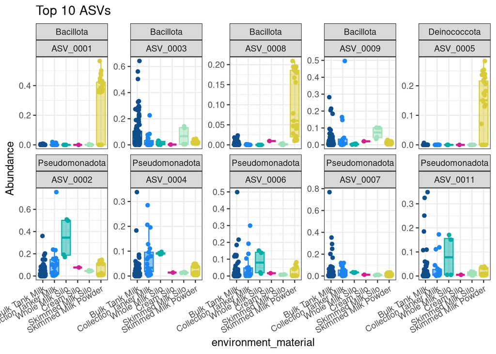

```r
ASV_df %>%
  filter(ASV %in% top_asvs) %>%
  ggplot(aes(x = environment_material, y = Abundance,
             fill = environment_material, color = environment_material)) +
  facet_wrap(Phylum ~ ASV, scales = "free_y", nrow = 2) +
  geom_boxplot(alpha = 0.5, outlier.shape = NA) +
  geom_jitter(width = 0.2) +
  theme_bw() +
  labs(title = "Top 10 ASVs") +
  scale_color_manual(values = environment_colors) +
  scale_fill_manual(values = environment_colors) +
  theme(axis.text.x = element_text(angle = 30, hjust = 1, vjust = 1),
        legend.position = "none")
```

INTERPRETATION #6: Were the most abundant ASVs in your dataset represented in your ASV-level plots? If not, please go back and plot them specifically. (Hint: Remember that we ordered our ASV names by abundance across the entire data set. Therefore, ASV_0001 will be the most abundant, ASV_0007 will be the 7th most abundant and so on.)

In order to view these most abundant ASVs, I made a separate plot (above). After viewing this plot, I realized I should probably do more mid-level analysis on the Bacillota and Pseudomonadota phyla (now carried out above), as all of the top ten most abundant ASVs are from these two phyla, besides ASV_0005 from the Deinococcota phylum.

### Bacillota ASVs

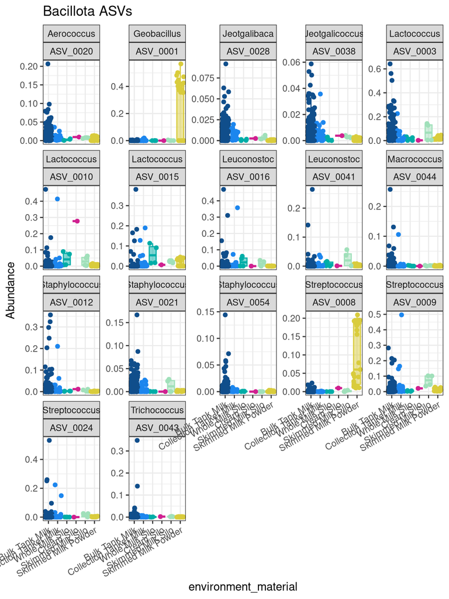

```r
top_bacillota_ASVs <-
  ASV_df %>%
  dplyr::filter(Phylum == "Bacillota") %>%
  group_by(ASV) %>%
  summarize(mean_Abundance = mean(Abundance)) %>%
  dplyr::filter(mean_Abundance > 0.005) %>%
  pull(ASV)


# Bacillota
# Plot ASVs
bacillota_asv_sample_type <-
  ASV_df %>%
  dplyr::filter(ASV %in% top_bacillota_ASVs) %>%
  # build the plot
  ggplot(aes(x = environment_material, y = Abundance,
             fill = environment_material, color = environment_material)) +
  facet_wrap(Genus~ASV, scales = "free_y", nrow = 4) +
  geom_boxplot(alpha = 0.5, outlier.shape = NA) + # outliers not plotted here in boxplot
  geom_jitter() +
  theme_bw() +
  labs(title = "Bacillota ASVs") +
  scale_color_manual(values = environment_colors) +
  scale_fill_manual(values = environment_colors) +
  theme(axis.text.x = element_text(angle = 30, hjust = 1, vjust = 1),
        legend.position = "none")

#View
bacillota_asv_sample_type
```

## Pseudomonadota ASVs

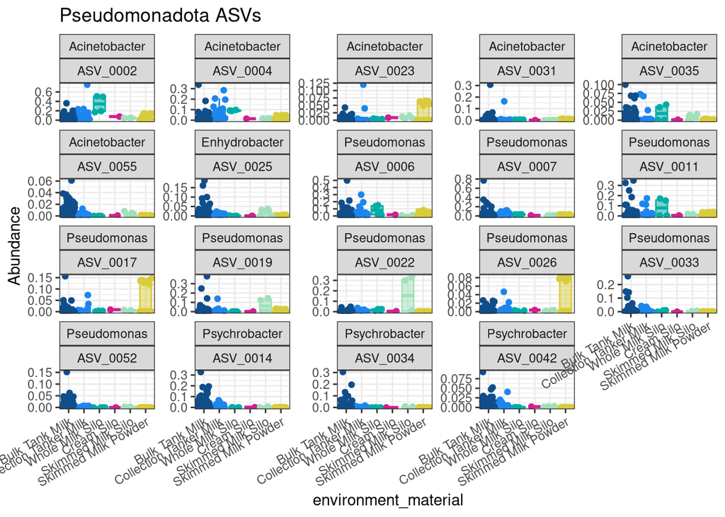

```r
top_pseudo_ASVs <-
  ASV_df %>%
  dplyr::filter(Phylum == "Pseudomonadota") %>%
  group_by(ASV) %>%
  summarize(mean_Abundance = mean(Abundance)) %>%
  dplyr::filter(mean_Abundance > 0.005) %>%
  pull(ASV)


# Pseudomonadota
# Plot ASVs
pseudo_asv_sample_type <-
  ASV_df %>%
  dplyr::filter(ASV %in% top_pseudo_ASVs) %>%
  # build the plot
  ggplot(aes(x = environment_material, y = Abundance,
             fill = environment_material, color = environment_material)) +
  facet_wrap(Genus~ASV, scales = "free_y", nrow = 4) +
  geom_boxplot(alpha = 0.5, outlier.shape = NA) + # outliers not plotted here in boxplot
  geom_jitter() +
  theme_bw() +
  labs(title = "Pseudomonadota ASVs") +
  scale_color_manual(values = environment_colors) +
  scale_fill_manual(values = environment_colors) +
  theme(axis.text.x = element_text(angle = 30, hjust = 1, vjust = 1),
        legend.position = "none")

#View
pseudo_asv_sample_type
```

*INTERPRETATION #7*: Please make some plots at the ASV level as it relates to your scientific question. Were there any ASVs that were especially related to trends that you saw? Did a specific phylogenetic group all show the same trends (e.g. like the Actinomycetota ASVs above)? Or did the ASVs have various, likely niche-specific responses (similar to the Cyanobacteriota above)?

After completing Interpretation #6, I realized it would probably be beneficial to plot the most abundant ASVs for Pseudomonadota and Bacillota, as these two phyla contained nine of the ten most abundant ASVs across all samples. In order to explore my scientific question, “How is microbial biodiversity modified as milk is processed in the dairy supply chain?”. I plotted the most abundant ASVs in Pseudomonadota and Bacillota above.

It was neat to see that, across the board with the phyla I looked at, there were no trends in phyla that remained consistent across all genera, and there were no trends in genera that remained consistent across all ASVs.

Without looking at Pseudomonadota at the ASV level I probably never would have noticed ASV_0026, ASV_0017, and ASV_0023 which all had the same pattern as ASV_0005 from the Deinococcota phylum. These ASVs have a much higher relative abundance in the Skimmed Milk Powder samples than the other, less processed sample types.

Similarly, without looking at Bacillota at the level of ASVs, I would not have seen that ASV_001 (Geobacillus) and ASV_0008 (Streptococcus) also followed this trend! With my scientific question, one of my main goals was to pick out the bacteria that had higher/lower relative abundance depending on how processed the sample was, so I was really pleased I was able to identify these ASVs in the data.

*INTERPRETATION #8*: Now, do a quick literature or google search and look back in the paper that you may be replicating (if applicable). Does your ASV-level changes represent something that is currently known? Or is this a novel result? What did you learn about this ASV or a group of ASVs in your dataset?

Yes, in my paper the results I have observed so far at the level of phylum and genus align fairly well with the results the authors obtained. I also want to note that they used OTUs and not ASVs in my paper.

In the paper, they saw that “The skimmed milk powder generated during the mid-lactation period had a microbial composition that was very different from that of raw milk; specifically, two thermophilic genera, Thermus and Geobacillus, were enriched”. It was so cool to see that the results I saw at the ASV level aligned with what was published in the paper.

Although for the homework I just did a very preliminary analysis at the ASV level, over the weekend I will do a more in-depth analysis of the literature, and will have time to make more plots to explore these results further! I also plan to redo a lot of these analyses after I have split up the samples into mid and late lactation periods.

Finally, one thing I would like to reiterate is that there was only one cream silo sample, but throughout the paper they use this singular sample to make conclusions about the microbial communities in cream silos. I just have to say that I personally am very skeptical of this approach.

# Final THoughts

In this document I successfully carried out a microbial compositional analysis of dairy samples across a skim milk processing pipeline. To do this I calculated th relative abundances of taxonomic groups at various levels (phylum, genus, ASVs) and then made some nice visualizations of how the microbial taxa vary across the dairy sample types. Due to time constraints (crazy last week of rotation/classes/TAing, did as much as I could) I unfortunately only ran statistical analysis on a few of these results.

Throughout this project the main scientific question I have been trying to ask is: How does microbial diversity change throughout the skim milk manufacturing process?

In this document, I explored two main hypotheses related to my overarching scientific question:

1. Refrigerated storage (pre-pasteurization) will result in an increased relative abundance of psychrotrophic spoilage-associated bacteria. After pasteurization, these psychrotrophic bacteria will diminish.

-Here, without confirming through statistical tests it seems as though as refrigerated storage (pre-pasteurization) results in an increased relative abundance of Acinetobacter, Lactococcus and Pseudomonas -The increased relative abundance of these psychrotrophic, food spoilage-associated genera can persist after pasteurization… they don’t necessarily decrease in relative abundance after pasteurization. -If I had more times I would definitely look further into this, take it down to the ASV level and run stats.

2. Skim milk powder will be enriched with thermophilic genera. -Here, without confirming through statistical tests it seems as though skim milk powder had increased relative abundance of both Thermus and Geobacillus (although there is a weird bimodal distribution)

# Final info for Reproducibility

## Check Render Time

```r
# Take the time now that we are at the end of the script
end_time <- Sys.time()
end_time
```

```
## [1] "2025-05-02 09:08:39 EDT"
```

```r
# Echo the elapsed time
elapsed_time <- round((end_time - start_time), 3)
elapsed_time
```

```
## Time difference of 5.79 mins
```